# Weather Conditions and their Influence on Human Mobility Patterns

GEO 880 - Computational Movement Analysis - Final Project

Author

Lars Weidinger & Javier Feller

Published

June 21, 2026

# Abstract

Ensuring safe and efficient pedestrian mobility requires a close understanding of its influencing factors. Weather conditions, particularly precipitation and temperature, are among important external factors affecting walking behaviour. In light of climate change with increasing temperatures and changing variability of precipitation, capturing these effects becomes increasingly important. Based on a case study of Zurich, this study examines how precipitation and temperature (external factors) influence both the spatial mobility extent (navigation capacity) and walking speed (motion capacity).

The results suggest that increasing temperature can lead to higher walking speed, except under very cold conditions. Furthermore, the spatial extent decreases with longer precipitation duration. While the data points are too few to detect significant relationships, this analysis shows initial evidence of weather-related effects on pedestrian mobility and serves as basis for further, more in-depth studies.

# Introduction

Since the dawn of human evolution, humans have walked across the surface of the earth. To this day, walking remains the most essential mode of transport, since almost all trips include some part of moving on foot (Giannoulaki and Christoforou (2024)). Pedestrian movement has therefore been studied in depth to create appealing and efficient walking infrastructure.

One of the most relevant variables in pedestrian movement is walking speed. According to Giannoulaki and Christoforou (2024), it depends on five factors: flow characteristics, pedestrian attributes, layout configuration, ambient conditions and behavioural patterns. This project focuses on ambient conditions, namely weather (temperature, precipitation), and its effect on pedestrian mobility patterns. As conceptual movement space, we use an unconstrained movement model (Laube (2009)), since walking mobility does not always occur on fixed routes.

Following the established framework for context-aware Movement Analysis (CAMA) Nathan et al. (2008), we investigate precipitation and temperature effects (external factors) on spatial extent (navigation capacity) and on speed levels (motion capacity), noting that weather can affect motion capacity both directly and indirectly.

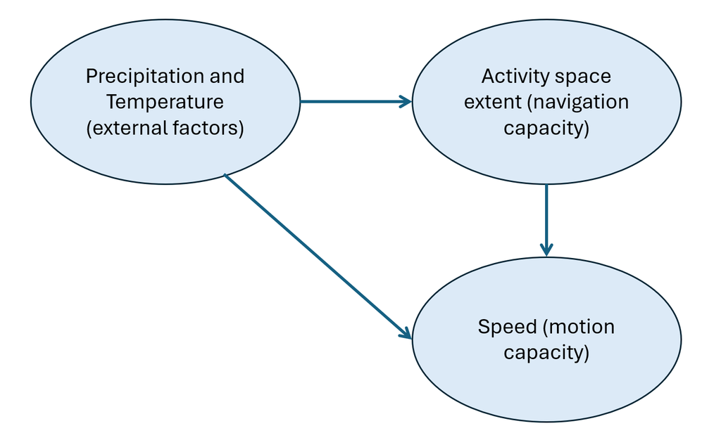

Adapted framework from Nathan et al. (2008)

In the northern hemisphere, low temperatures and precipitation are generally associated with poorer walking conditions, as rain, snow and ice reduce pavement quality and require more cautious, slower movement (Montigny, Ling, and Zacharias (2012)). However, the relationship is complex since pedestrians may also increase their speed under unfavourable weather to minimize exposure and reach their destination faster (Giannoulaki and Christoforou (2024)). Warmer temperatures up to a certain threshold encourage walking, while higher temperatures (23°C or more) may lead pedestrians to seek shade and alter their routes (Montigny, Ling, and Zacharias (2012)). The speed increase in heat was also found by Rotton, Shats, and Standers (1990), which is explained through the Yerkes–Dodson law, where moderate arousal (=heat) improves performance while excessive stress reduces it (a U-shaped curve) (Yerkes and Dodson (1908)). Furthermore, walking may also serve as a heat-production mechanism in cold temperatures, resulting in faster speeds (Shuichi et al. (2021)).

Precipitation is one of the strongest determinants of pedestrian activity. Rainfall significantly reduces pedestrian traffic, and this effect extends beyond the immediate weather event, as travellers may anticipate rainfall and adjust their mobility decisions in advance (Zhao et al. (2019)).

This project focuses on the impact of temperature and precipitation on pedestrian mobility patterns and walking behaviour, leading to the following Research Questions (RQ):  
I) How does temperature affect walking speed?  
II) How does precipitation affect walking speed?  
III) How do temperature and precipitation affect the spatial extent of activity spaces?  
IV) Do different temporal scales of the weather data matter?

Since previous research showed the importance and sensitivity of varying scale (Laube and Purves (2011), Zhao et al. (2019)), special attention is given to it in this analysis. For the weather station data, we account for the effect of spatial scale selection comparing city-level vs. station-level analysis as well as considering varying temporal scale with daily, hourly and 15 min weather data. Thus, we also perform a small cross-scale movement analysis. For the mobility data, we don’t include a cross-scale movement analysis, but discuss our choices and parameters extensively.

# Material and Methods

## Load Packages

```r
library(pacman)

# Load and if not found in the library will attempt to install the package
pacman::p_load(here,
               sf,
               readr,
               tmap,
               dplyr,
               ggplot2,
               tidyr,
               jsonlite, # to import JSON files
               lubridate, # temporal import from JSON file
               tidyverse,
               leaflet, # interactive maps, more personal experience than on tmap
               tmap, # interactive maps
               concaveman, # construct concave hulls
               gstat, # for IDW
               stars, # to create a grid
               purrr,
               devtools, # for the wordcountaddin to work
               wordcountaddin, # counts words and characters
               install = TRUE)
```

## Import & Preprocess Data

**preprocessing**

```r
source("preprocessing.R") # this runs the whole preprocessing file

# See the preprocessing.R file where we import:
# - weather data (weather_daily_df, weather_hourly_df, meteoblue_weather_data)
# - weather station location data (weather_stations_sf, meteoblue_stations)
# - tracking data (google_timeline_sf_lv95)
# - city boundary data (stadtgrenze)

# set CRS
crs_lv95  <- 2056
crs_wgs84 <- 4326
```

## Weather Daily (Voronoi Polygon)

### Weather Stations

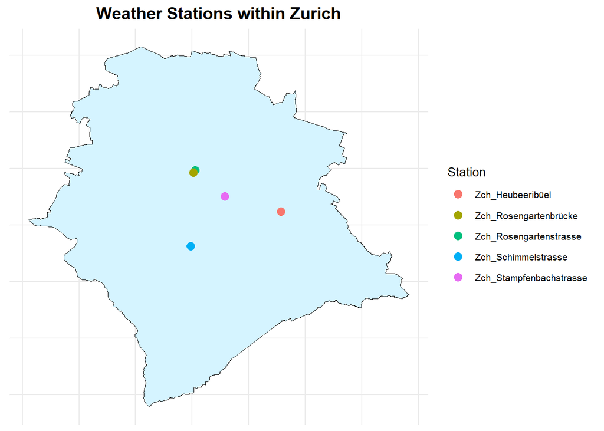

```r
ggplot() +
  geom_sf(data = stadtgrenze, fill = "#D5F4FF", color = "black") +
  geom_sf(data = weather_stations_sf, aes(color = ID), size = 3) +

  coord_sf(datum = crs_lv95) +

  labs(
    title = "Weather Stations within Zurich",
    color = "Station",
    x = "Easting [m]",
    y = "Northing [m]") +

  theme_minimal() +

  theme(
    plot.title = element_text(size = 14, face = "bold", hjust = 0.5),
    legend.title = element_text(size = 10),
    legend.text = element_text(size = 8),
    axis.text = element_blank(),
    axis.title = element_blank()
    )
```

### Construct Voronoi Polygons around Stations

Since we need to assign the weather data to our GPS fixes and later our segments we need to relate the two datasets spatially. For that, we construct Voronoi polygons around the measuring stations. Later we can then assign each Google timeline fix the weather values from the station it is closest to (= inside the Voronoi polygon). This method is rather simple but very effective.

```r
# both datasets are in CH1903+

# create a union of points
pts_union <- st_union(weather_stations_sf)

# create Voronoi tessellation with an envelope
# st_voronoi has an envelope argument. Instead of generating a huge (or to small) tessellation we can set the scope here
envelope_stadtgrenze <- st_as_sfc(st_bbox(stadtgrenze))

voronoi <- st_voronoi(
  pts_union,
  envelope = envelope_stadtgrenze)

# extract polygons
voronoi_polygons <- st_collection_extract(voronoi, "POLYGON")

# convert to sf object
voronoi_sf <- st_sf(
  ID = weather_stations_sf$ID,
  geometry = st_cast(voronoi_polygons))

# clip to city boundary
voronoi_clipped <- sf::st_intersection(voronoi_sf, stadtgrenze)
```

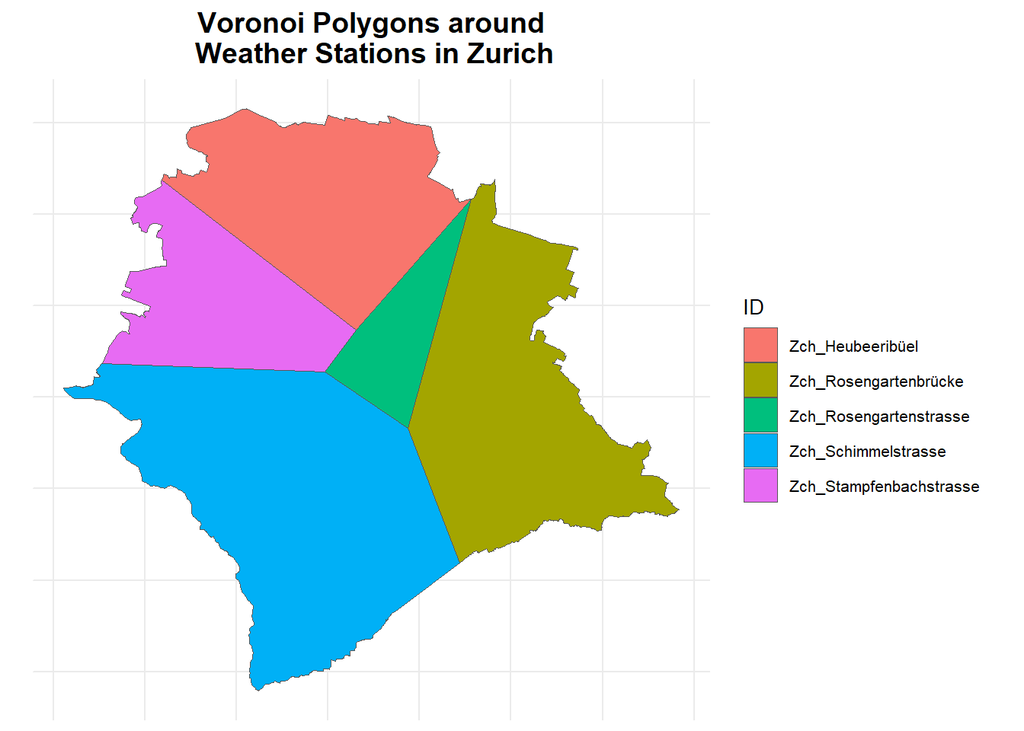

```r
ggplot() +
  geom_sf(data = voronoi_clipped, aes(fill = ID)) +

  coord_sf(datum = crs_lv95) +

  labs(
    title = "Voronoi Polygons around\n Weather Stations in Zurich",
    color = "Station",
    x = "Easting [m]",
    y = "Northing [m]") +

  theme_minimal() +

  theme(
    plot.title = element_text(size = 14, face = "bold", hjust = 0.5),
    legend.title = element_text(size = 10),
    legend.text = element_text(size = 8),
    axis.text = element_blank(),
    axis.title = element_blank()
    )
```

### Assign Google Timeline to Voronoi Polygons

```r
# We can now use a spatial join to assign the corresponding weather station to each of the Google timeline fixes.

# both datasets are in CH1903+

# spatial join: assign polygon attributes (ID) to points
google_timeline_sf_lv95 <- st_join(
  google_timeline_sf_lv95,
  voronoi_clipped["ID"],
  join = st_within) |>

  # Since we traveled quite a lot outside of the city of Zurich, we omit the data
  # outside the city (NA values), which is approximately 60% of the data points.
  drop_na() # omit NA values (quite a lot of them)
```

[figure not shown]

```r
# visualise timeline points
ggplot() +
  geom_sf(data = stadtgrenze, fill = "#D5F4FF", color = "black") +

  geom_sf(data = google_timeline_sf_lv95, color = "orange", size = 0.6) +


  coord_sf(datum = crs_lv95) +

  labs(
    title = "Google Timeline Data Points\n within Zurich",
    color = "Stop",
    x = "Easting [m]",
    y = "Northing [m]") +

  theme_minimal() +

  theme(
    plot.title = element_text(size = 14, face = "bold", hjust = 0.5),
    legend.title = element_text(size = 10),
    legend.text = element_text(size = 8),
    axis.text = element_blank(),
    axis.title = element_blank()
    )
```

### Assign Weather Data to Google Timeline

```r
# Now that we have assigned each data point to its closest weather station, we need to assign them their relevant weather values. We decided on using temperature (T) and rain (RainDur). One problem is, that the station Heubeeribüel does not collect RainDur information.

# based on the exercises of week 5, Task 3 ff we first create a join key so that we can later match them exactly

google_timeline_sf_lv95 <- google_timeline_sf_lv95 |>
  mutate(
    Date = as.Date(time)) # since we only have one measurement per night

weather_daily_df <- weather_daily_df |>
  mutate(
    Date = as.Date(Datum)) # since we only have one measurement per night
```

```r
# prepare weather data
weather_daily_df_wide <- weather_daily_df |>
  filter(Parameter %in% c("T", "RainDur")) |> # we only want T and RainDur
  select(Date, Standort, Parameter, Wert) |>
  pivot_wider(                               # we need the parameters as columns
    names_from = Parameter,
    values_from = Wert
  ) |>
  rename(
    Temperature = T,
    RainDur = RainDur,
    ID = Standort
  )
```

```r
# join the two datasets
google_timeline_weather <- google_timeline_sf_lv95 |>
  left_join(
    weather_daily_df_wide,
    by = c("Date", "ID")
  )
```

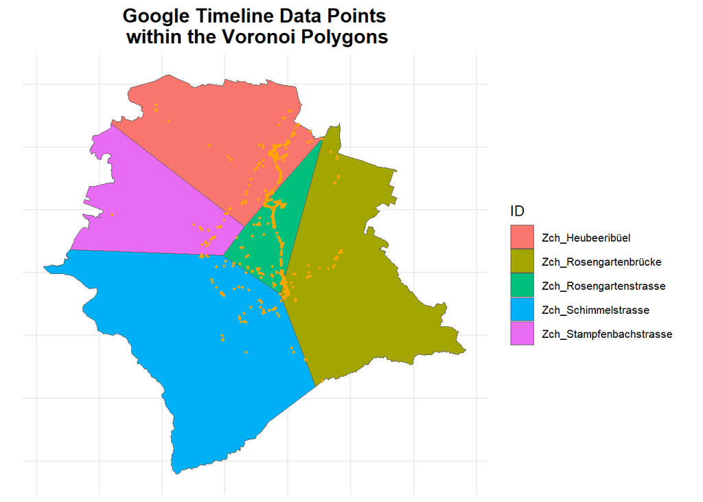

```r
# visualise timeline points with voronoi polygons
ggplot() +
  geom_sf(data = voronoi_clipped, aes(fill = ID)) +

  geom_sf(data = google_timeline_sf_lv95, color = "orange", size = 0.6) +


  coord_sf(datum = crs_lv95) +

  labs(
    title = "Google Timeline Data Points\n within the Voronoi Polygons",
    color = "Stop",
    x = "Easting [m]",
    y = "Northing [m]") +

  theme_minimal() +

  theme(
    plot.title = element_text(size = 14, face = "bold", hjust = 0.5),
    legend.title = element_text(size = 10),
    legend.text = element_text(size = 8),
    axis.text = element_blank(),
    axis.title = element_blank()
    )
```

## Visualise Activity Space (Concave Hulls)

We decided to use concave hulls rather than convex hulls since they are less prone to outliers. Even though there are some convex hull implementations that allow for certain variables to be manipulated in order to exclude outliers (e.g. adehabitatHR::mcp()), the concave hull is more suited for our use case. We could have also used Alpha shapes (alphahull::) which accounts for holes in our data but this is not needed since we are dealing with continuous travel data (Weibel (2024)).

As an alternative, we could have used the Standard Devitational Ellipse (SDE), which forms a closed shape that while representing distributional properties of the point set it does not enclose all points. This would have been potentially more fitting, since the Google timeline data does not capture the movement between fixes, therefore single fixes could distort the concave hulls.

### Construct Concave Hulls

```r
# In the first approach we called concaveman() on the entire sfc column (all geometries at once), not on each row individually. It computed one hull over all points and that same result gets recycled into every row which resulted in all the hulls being the same. We asked Claude AI (Model Sonnet 4.6) for help and it delivered the following solution using lapply.

# Step 1: union points by date
google_timeline_hulls <- google_timeline_sf_lv95 |>
  group_by(Date) |>
  summarise(geometry = st_union(geometry), .groups = "drop") |>
  st_as_sf()

# Step 2: build concave hull for each date
hulls_list <- lapply(google_timeline_hulls$geometry, function(g) {
  coords <- st_coordinates(g)[, c("X", "Y")]

  # need at least 3 unique points for a polygon
  if (is.null(nrow(coords)) || nrow(unique(coords)) < 3) return(NA)

  st_polygon(list(concaveman(coords)))
})

# Step 3: check which dates failed
failed_dates <- google_timeline_hulls$Date[sapply(hulls_list, function(x) identical(x, NA))]
print(failed_dates)  # inspect which dates are problematic
```

```
Date of length 0
```

```r
# Step 4: remove failed dates and assign geometry
google_timeline_hulls <- google_timeline_hulls[!sapply(hulls_list, function(x) identical(x, NA)), ]

hulls_list <- hulls_list[!sapply(hulls_list, function(x) identical(x, NA))]

# Step 5: assign hulls back as sfc column
google_timeline_hulls$geometry <- st_sfc(hulls_list, crs = st_crs(google_timeline_sf_lv95))
```

```r
# calculate area
google_timeline_hulls <- google_timeline_hulls |>
  mutate(
    area_m2 = as.numeric(st_area(geometry)),
    area_km2 = area_m2 / 1000000)
```

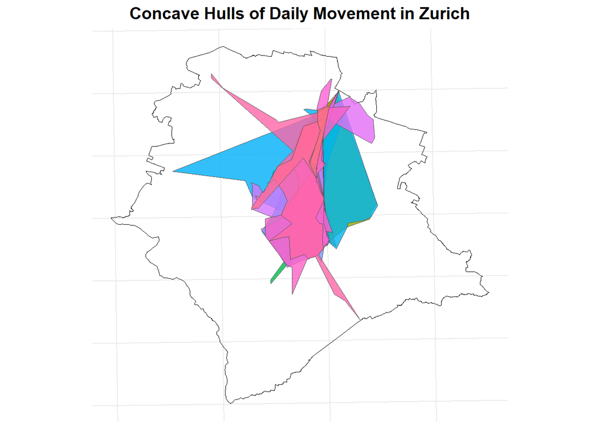

```r
# visualise concave hulls
ggplot() +
  geom_sf(data = stadtgrenze, fill = "transparent", color = "black") +

  geom_sf(data = google_timeline_hulls, aes(fill = as.factor(Date)), alpha = 0.8) +

  scale_fill_discrete(guide = "none") +

  labs(
    title = "Concave Hulls of Daily Movement in Zurich",
    x = "Easting [m]",
    y = "Northing [m]") +

  theme_minimal() +

  theme(
    plot.title = element_text(size = 14, face = "bold", hjust = 0.5),
    legend.title = element_text(size = 10),
    legend.text = element_text(size = 8),
    axis.text = element_blank(),
    axis.title = element_blank()
    )
```

### Assign Weather Values

```r
# average weather values across whole hull
daily_weather <- google_timeline_weather |>
  st_drop_geometry() |>
  group_by(Date) |>
  summarise(
    Temperature = mean(Temperature, na.rm = TRUE),
    RainDur = mean(RainDur, na.rm = TRUE)
  )

daily_hulls_weather <- google_timeline_hulls |>
  left_join(daily_weather, by = "Date")
```

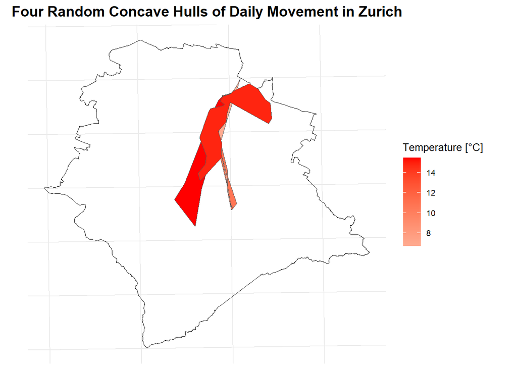

```r
# visualise concave hulls with weather data
ggplot() +
  geom_sf(data = stadtgrenze, fill = "transparent", color = "black") +

  geom_sf(data = daily_hulls_weather[c(1, 8, 24, 35), ], aes(fill = Temperature), alpha = 1) +

  scale_fill_gradient2(low = "blue", mid = "white", high = "red", midpoint = 0, name = "Temperature [°C]") +

  labs(
    title = "Four Random Concave Hulls of Daily Movement in Zurich",
    color = "Temperature",
    x = "Easting [m]",
    y = "Northing [m]") +

  theme_minimal() +

  theme(
    plot.title = element_text(size = 14, face = "bold", hjust = 0.5),
    legend.title = element_text(size = 10),
    legend.text = element_text(size = 8),
    axis.text = element_blank(),
    axis.title = element_blank()
    )
```

## Weather Daily (Field)

We only have weather measurements at at a handful of stations across the city. Assigning each location fix the weather data of the Voronoi polygon of the station is simplistic. Weather changes rather gradually across space, a more “fluid” approach would be better. That is why we decided on using Inverse Distance Weighting (IDW), which is a simple approach to generate gradually changing values across space using some sort of tessellation.

### Inverse Distance Weighting (IDW)

```r
# With only few stations the interpolation accuracy will be low. We are not capturing real microclimate variation like urban heat island effects or cooling green spaces and water bodies. But since we plan on repeating our method with the finer scaled Meteoblue stations, we decided on applying the IDW method.

# Since we do not want to compute a full raster for every day we will do a point-wise IDW prediction directly at each location fix's coordinates, using all weather station information. A raster per timestamp needs a lot of computation time and we only need the value at the fix's exact coordinates. Point-wise IDW is just a weighted average of all the distance, which takes much less time and we avoid avoid having to manage hundreds of rasters.

# this code chunk was constructed with the help of Claude (Sonnet 4.6)

idw_for_date <- function(fixes_date, stations_date, power = 2) {
  # fixes_date: sf object for this date
  # stations_date: sf object with Temperature, RainDur for this date
  # power = 2 is the standard value

  # full distance matrix: n_fixes x n_stations
  dist_mat <- st_distance(fixes_date, stations_date)
  dist_mat <- matrix(as.numeric(dist_mat), nrow = nrow(fixes_date), ncol = nrow(stations_date))

  # avoid division by zero
  dist_mat[dist_mat == 0] <- 1e-9

  weights <- 1 / (dist_mat^power)
  weights_norm <- weights / rowSums(weights)

  fixes_date |>
    mutate(
      Temperature_IDW = as.numeric(weights_norm %*% stations_date$Temperature),

      RainDur_IDW = apply(weights_norm, 1,
                          function(w) {
                            valid <- !is.na(stations_date$RainDur) # ignore stations with missing RainDur

                            if(sum(valid) == 0) {
                              return(NA)
                              }

                            w_valid <- w[valid]
                            rain_valid <- stations_date$RainDur[valid]

                            # renormalize weights only along valid stations
                            w_valid <- w_valid / sum(w_valid)

                            sum(w_valid * rain_valid)
                            }
                          )
      )
}


# apply per date (groups are small: one per day x n_stations)
unique_dates <- unique(google_timeline_sf_lv95$Date)

result_list <- map(unique_dates, function(d) {
  fixes_date <- google_timeline_sf_lv95 |>
    filter(Date == d)
  stations_date <- weather_daily_df_wide |>
    filter(Date == d) |>
    inner_join(st_drop_geometry(weather_stations_sf) |>
                 select(ID), by = "ID") |>
    left_join(weather_stations_sf |>
                select(ID, geometry), by = "ID") |>
    st_as_sf()

  if (nrow(stations_date) == 0) {
    fixes_date$Temperature_IDW <- NA
    fixes_date$RainDur_IDW <- NA
    return(fixes_date)
  }

  idw_for_date(fixes_date, stations_date)
})

google_timeline_weather_daily <- bind_rows(result_list)
```

### Assign Weather Values

```r
# average weather values across whole hull
daily_weather_field <- google_timeline_weather_daily |>
  st_drop_geometry() |>
  group_by(Date) |>
  summarise(
    Temperature = mean(Temperature_IDW, na.rm = TRUE),
    RainDur = mean(RainDur_IDW, na.rm = TRUE)
  )

daily_hulls_weather_field <- google_timeline_hulls |>
  left_join(daily_weather_field, by = "Date")
```